# Time Series: A First Course with Bootstrap Starter

# Lesson 13: Linear Prediction of Time Series

- Now we focus on linear prediction. This is the same as the conditional expectation when the distribution is Gaussian, or in the case of a linear process (like the AR(1)).

## Paradigm 4.6.1. Linear Prediction and the Yule-Walker Equations

- Let $\{ X_t \}$ be a mean zero weakly stationary time series in ${\mathbb L}_2$.
- Say $\mathcal{M}$ is the linear span of the random variables $X_1, \ldots, X_n$.
- Suppose we wish to predict $Y$ from $X_1, \ldots, X_n$. Then the minimal MSE *linear* predictor $\widehat{Y}$ is obtained by projection onto $\mathcal{M}$.
- The orthogonality principle says that
  $$0 = \langle Y - \widehat{Y}, X_t \rangle$$
  for $t = 1, \ldots, n$. These are the *normal equations*. They can be rewritten as
  $$\langle \widehat{Y}, X_t \rangle = \langle Y, X_t \rangle.$$

### One-step Ahead Forecasting

- Suppose $Y = X_{n+1}$.
- Because $\widehat{X}_{n+1} \in \mathcal{M}$, there exist constants $\phi_1, \ldots, \phi_n$ such that
  $$\widehat{X}_{n+1} = \phi_1 X_n + \ldots + \phi_n X_1 =
  \sum_{j=1}^n \phi_j X_{n+1-j}.$$
- Then the normal equations imply that for any $1 \leq t \leq n$,
  $$\begin{align*}
  \langle \widehat{X}_{n+1}, X_t \rangle & = \langle X_{n+1}, X_t \rangle \\
  \sum_{j=1}^n \phi_j \langle {X}_{n+1-j}, X_t \rangle & = \langle X_{n+1}, X_t \rangle \\
  \sum_{j=1}^n \phi_j \gamma (n+1-j-t) & = \gamma (n+1 - t).
  \end{align*}$$
- This is now linear algebra! Let $\underline{\phi}$ and $\underline{\gamma}_n$ be vectors
  $$\underline{\phi} = \left[ \begin{array}{c} \phi_1 \\ \phi_2 \\ \vdots \\ \phi_n
  \end{array} \right] \qquad
  \underline{\gamma}_n = \left[ \begin{array}{c} \gamma (1) \\ \gamma (2) \\ \vdots \\
  \gamma (n) \end{array} \right].$$
  And recall that $\Gamma_n$ is the $n$-dimensional Toeplitz matrix of autocovariances.
- Now our normal equations are
  $$\Gamma_n \, \underline{\phi} = \underline{\gamma}_n.$$
  These are called the *Yule-Walker* equations (i.e., normal equations associated with one-step ahead prediction).
- The solution is
  $$\underline{\phi} = \Gamma_n^{-1} \, \underline{\gamma}_n.$$
- The prediction MSE can be derived:
  $${ \| X_{n+1} - \widehat{X}_{n+1} \| }^2 = \gamma (0) - \underline{\gamma}^{\prime}_n \,
  \Gamma_n^{-1} \, \underline{\gamma}_n.$$

## Example 4.6.4. Order One Moving Average

- Consider an MA(1) process $\{ X_t \}$ given by $X_t = Z_t + \theta Z_{t-1}$, for a white noise $\{ Z_t \}$ with variance $\sigma^2$.
- Suppose we want to forecast one-step ahead with sample size $n=2$.
- The Yule-Walker equations are
  $$\underline{\phi} = { \left[ \begin{array}{cc} (1 + \theta^2) \sigma^2 & \theta \sigma^2 \\
  \theta \sigma^2 & (1 + \theta^2) \sigma^2 \end{array} \right] }^{-1} \,
  \left[ \begin{array}{c} \theta \sigma^2 \\ 0 \end{array} \right]
  = {(1 + \theta^2 + \theta^4)}^{-1} \, \left[ \begin{array}{c} (1 + \theta^2) \theta \\
  - \theta^2 \end{array} \right].$$
- This means that the forecast is
  $$\widehat{X}_{3} = \frac{(1 + \theta^2) \theta }{1 + \theta^2 + \theta^4} X_2
  + \frac{ - \theta^2 }{1 + \theta^2 + \theta^4} X_1.$$
- The prediction MSE is
  $$\sigma^2 \frac{ (1 + \theta^2) ( 1 + \theta^4) }{1 + \theta^2 + \theta^4}.$$
- This formula also applies if we want to predict $X_{n+1}$ only using $X_n$ and $X_{n-1}$.

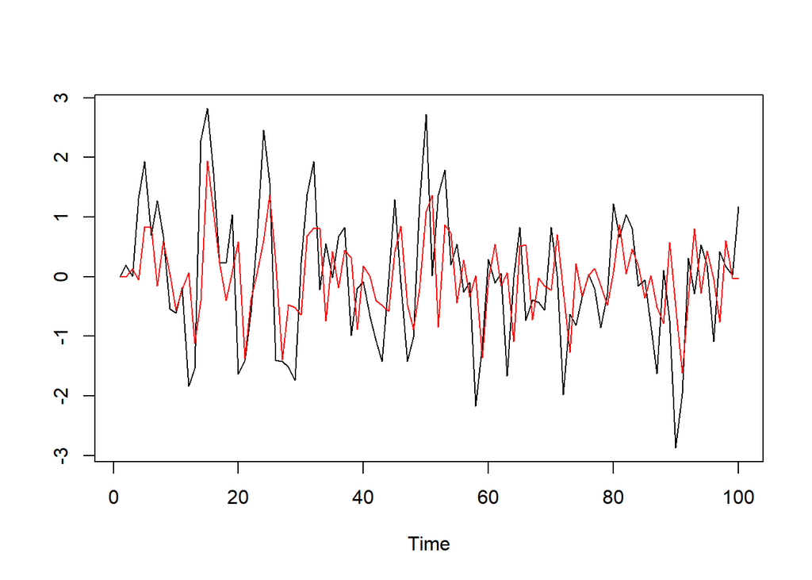

```r
set.seed(777)
n <- 100
z <- rnorm(n+1)     # Gaussian input
theta <- .8
x <- z[-1] + theta*z[-(n+1)]
xhat <- rep(0,n)
phi1 <- (1+theta^2)*theta/(1+theta^2+theta^4)
phi2 <- -theta^2/(1+theta^2+theta^4)
for(t in 3:n)
{
  xhat[t] <- phi1*x[t-1] + phi2*x[t-2]
}
plot(ts(x),xlab="Time",ylab="",main="")
lines(ts(xhat),col=2)
```